# 0. Loading required libraries

First we load all the libraries needed for analysis.

```python
import numpy as np
import pandas as pd
import tqdm
import matplotlib.pyplot as plt
from scipy.stats import entropy, chi2_contingency, norm
import scipy.spatial.distance as distance
import statsmodels.stats.multitest as multitest
from folktables import ACSDataSource
from sklearn.linear_model import LogisticRegression
```

# 1. Testing for distribution shifts

In terms of hypothesis testing problems, the presence of distribution shifts can be modelled as testing for significant differences/effects. Asumme we observe two samples over variables $V$. We are now interested in understanding whether both samples are drawn from the same underlying distribution (i.e. if there is a distribution shift). Thus, we test the following hypothesis: $$H_0:P_a(V) = P_b(V) \text{ vs } H_1:P_a(V) \neq P_b(V)\text{, where a and b denote the two different samples} $$

Let's examine this problem by focussing on an example. Taken from example 4.1 in [Plečko and Bareinboim (2024)](https://causalai.net/r90.pdf), we assume we have access to the hiring data of two startups from location A. Additionally, we observe the data for one startup at location B. The variables are given by:

- $Y \in \{0,1\}$, denoting the hiring decision {no,yes}
- $X \in \{0,1\}$, denoting the applicant's gender {female,male}
- $Z \in \{0,1\}$, denoting the applicant's age group {young,old}
- $W \in \{0,1\}$, denoting whether the applicant holds a Phd {no,yes}

The underlying data-generating structural causal model (SCM) for location A is given by: \begin{align*} U &\leftarrow \textit{N}(0,1)\\ X &\leftarrow \textit{Bernoulli}(\text{expit}(U))\\ Z &\leftarrow \textit{Bernoulli}(\text{expit}(U))\\ W &\leftarrow \textit{Bernoulli}(0.3|X-Z| + 0.1)\\ Y &\leftarrow \textit{Bernoulli}(0.2(X+Z-2XZ) + 0.25W + 0.02) \end{align*}

Note that we adapted the original example such that:

- $W$ has parents $X$ and $Z$
- $Y$ has always non-zero probability of $Y=1$

Additionally, location B has a different mechanism for the hiring decision $Y$, given by: \begin{align*} Y &\leftarrow \textit{Bernoulli}(0.2(X+Z-2XZ) + 0.25W + 0.11) \end{align*}

In reality we usually only have access to the observational distribution over $V = \{X,Z,W,Y\}$ and not the underlying SCM. We now generate two samples for location A and one for location B.  
All samples are of size $n=1000$.

```python
#Create sample hiring data

def hiring_data(shift, n=1000,d=0.09):

    np.random.seed(1)

    U = np.random.normal(0, 1, n)
    X = np.random.binomial(1,np.exp(U)/(1+np.exp(U)),n)
    Z = np.random.binomial(1,np.exp(U)/(1+np.exp(U)),n)
    W = np.random.binomial(1,0.3*(np.abs(X-Z)) + 0.1,n)
    Y = np.random.binomial(1,(1/5)*(X+Z-2*X*Z)+(1/4)*W+0.02,n)
    sample_1 = pd.DataFrame({'X':X, 'Z':Z, 'W':W, 'Y':Y})

    if shift == 1:
        U = np.random.normal(0, 1, n)
        X = np.random.binomial(1,np.exp(U)/(1+np.exp(U)),n)
        Z = np.random.binomial(1,np.exp(U)/(1+np.exp(U)),n)
        W = np.random.binomial(1,0.3*(np.abs(X-Z)) + 0.1,n)
        Y = np.random.binomial(1,(1/5)*(X+Z-2*X*Z)+(1/4)*W + 0.02 + d,n)
        sample_2 = pd.DataFrame({'X':X, 'Z':Z, 'W':W, 'Y':Y})

    else:
        U = np.random.normal(0, 1, n)
        X = np.random.binomial(1,np.exp(U)/(1+np.exp(U)),n)
        Z = np.random.binomial(1,np.exp(U)/(1+np.exp(U)),n)
        W = np.random.binomial(1,0.3*(np.abs(X-Z)) + 0.1,n)
        Y = np.random.binomial(1,(1/5)*(X+Z-2*X*Z)+(1/4)*W+0.02,n)

        sample_2 = pd.DataFrame({'X':X, 'Z':Z, 'W':W, 'Y':Y})

    return sample_1, sample_2

sample_1, sample_2 = hiring_data(0)
_ , sample_3 = hiring_data(1)
```

We are interested in testing whether the probability of an applicant being hired based on gender, age and education level is the same between pairs:

- Sample 1 vs Sample 2
- Sample 1 vs Sample 3

As we have access to the true SCM, we know that the first pair represents location A and is drawn from the same distribution. The latter pair is drawn from different distributions. However, we will now try to answer the question solely based on the observational distributions. Specifically we test the hypotheses: \begin{align} H_{0}: P_{s_1}(Y|X,Z,W) &= P_{s_2}(Y|X,Z,W)\quad \text{vs} \quad H_{1}: P_{s_1}(Y|X,Z,W) \neq P_{s_2}(Y|X,Z,W)\\ H_{0}: P_{s_1}(Y|X,Z,W) &= P_{s_3}(Y|X,Z,W)\quad \text{vs} \quad H_{1}: P_{s_1}(Y|X,Z,W) \neq P_{s_3}(Y|X,Z,W)\\ \end{align} Generally, there is not a one-size-fits all solution to the problem and we need to choose task-specific procedures. In this case all variables are discrete and binary. Thus, one simple method for assessing the hypotheses is to perform a bootstrapped based test.

## 1.1 Bootstrap test

Note that in this case, both (1) and (2) can be rewritten to testing: \begin{align*} H_{0}: P_{s_1}(Y=1|X,Z,W) - P_{s_2}(Y=1|X,Z,W) &= 0 \quad \text{vs} \quad H_{1}: P_{s_1}(Y=1|X,Z,W) - P_{s_2}(Y=1|X,Z,W) \neq 0\\ H_{0}: P_{s_1}(Y=1|X,Z,W) - P_{s_3}(Y=1|X,Z,W) &= 0 \quad \text{vs} \quad H_{1}: P_{s_1}(Y=1|X,Z,W) - P_{s_3}(Y=1|X,Z,W) \neq 0\\ \end{align*} Also, there are $2^3=8$ combinations of $X,Z$ and $W$. For each of these we can test the hypothesis whether the observed difference is significantly different from 0. However, let's first compute the corresponding conditionals for all samples.

```python
#compute conditionals of Y=1 on X,Z,W for all samples
y_conditional_on_xzw_sample_1 = sample_1.groupby(['X','Z','W'])['Y'].mean().reset_index()
y_conditional_on_xzw_sample_2 = sample_2.groupby(['X','Z','W'])['Y'].mean().reset_index()
y_conditional_on_xzw_sample_3 = sample_3.groupby(['X','Z','W'])['Y'].mean().reset_index()

#compare difference in conditionals
#between sample 1 vs sample 2
y_conditional_difference_sample_1_sample_2 = y_conditional_on_xzw_sample_1.merge(y_conditional_on_xzw_sample_2, on=['X','Z','W'], suffixes=('_s1','_s2'))
y_conditional_difference_sample_1_sample_2['Difference'] = y_conditional_difference_sample_1_sample_2['Y_s1'] - y_conditional_difference_sample_1_sample_2['Y_s2']
#between sample 1 vs sample 3
y_conditional_difference_sample_1_sample_3 = y_conditional_on_xzw_sample_1.merge(y_conditional_on_xzw_sample_3, on=['X','Z','W'], suffixes=('_s1','_s3'))
y_conditional_difference_sample_1_sample_3['Difference'] = y_conditional_difference_sample_1_sample_3['Y_s1'] - y_conditional_difference_sample_1_sample_3['Y_s3']

#Store the conditional probabilities as index
index = ['P(Y=1|X=0,Z=0,W=0)', 'P(Y=1|X=0,Z=0,W=1)', 'P(Y=1|X=0,Z=1,W=0)', 'P(Y=1|X=0,Z=1,W=1)', 'P(Y=1|X=1,Z=0,W=0)', 'P(Y=1|X=1,Z=0,W=1)', 'P(Y=1|X=1,Z=1,W=0)', 'P(Y=1|X=1,Z=1,W=1)']

print(f"Conditional probabilities of Y=1 given X,Z,W for sample 1, sample 2 and their difference:\n\n{np.round(y_conditional_difference_sample_1_sample_2,4)}\n")
print(f"The average difference between sample 1 and sample 2 is {np.round(y_conditional_difference_sample_1_sample_2['Difference'].mean(),4)}\n")
print(f"Conditional probabilities of Y=1 given X,Z,W for sample 1, sample 3 and their difference:\n\n{np.round(y_conditional_difference_sample_1_sample_3,4)}\n")
print(f"The average difference between sample 1 and sample 3 is {np.round(y_conditional_difference_sample_1_sample_3['Difference'].mean(),4)}\n")
```

```
Conditional probabilities of Y=1 given X,Z,W for sample 1, sample 2 and their difference:

   X  Z  W    Y_s1    Y_s2  Difference
0  0  0  0  0.0196  0.0278     -0.0082
1  0  0  1  0.4167  0.2353      0.1814
2  0  1  0  0.2581  0.2578      0.0003
3  0  1  1  0.4103  0.5270     -0.1168
4  1  0  0  0.2261  0.1832      0.0429
5  1  0  1  0.4112  0.4848     -0.0736
6  1  1  0  0.0256  0.0107      0.0150
7  1  1  1  0.2917  0.2059      0.0858

The average difference between sample 1 and sample 2 is 0.0158

Conditional probabilities of Y=1 given X,Z,W for sample 1, sample 3 and their difference:

   X  Z  W    Y_s1    Y_s3  Difference
0  0  0  0  0.0196  0.1032     -0.0836
1  0  0  1  0.4167  0.3824      0.0343
2  0  1  0  0.2581  0.3594     -0.1013
3  0  1  1  0.4103  0.5000     -0.0897
4  1  0  0  0.2261  0.2595     -0.0335
5  1  0  1  0.4112  0.5152     -0.1039
6  1  1  0  0.0256  0.1068     -0.0811
7  1  1  1  0.2917  0.3529     -0.0613

The average difference between sample 1 and sample 3 is -0.065
```

On a aggregated level we can see that the absolute difference is higher between sample 1 and sample 3 than between sample 1 and sample 2. This is in line with our knowledge of the underlying data-generating mechanisms. However, there are a few things to note.

Although sample 1 and sample 2 is generated by the same SCM, the individual and average differences are $\neq0$. This is due to sampling variation as the SCM is not a fully deterministic process, but involves sampling from some probability distribution.

This is also the reason as to why some absolute differences between sample 1 and sample 2 are higher than for sample 1 and sample 3.

For instance, we test the following for sample 1 and sample 2. \begin{align*} H_{0,1}: P_{s_1}(Y=1|X=0,Z=0,W=0) - P_{s_2}(Y=1|X=0,Z=0,W=0) = 0 \quad &\text{vs} \quad H_{1,1}: P_{s_1}(Y=1|X=0,Z=0,W=0) - P_{s_2}(Y=1|X=0,Z=0,W=0) \neq 0\\ H_{0,2}: P_{s_1}(Y=1|X=0,Z=0,W=1) - P_{s_2}(Y=1|X=0,Z=0,W=1) = 0 \quad &\text{vs} \quad H_{1,2}: P_{s_1}(Y=1|X=0,Z=0,W=1) - P_{s_2}(Y=1|X=0,Z=0,W=1) \neq 0\\ ...\\ ...\\ H_{0,8}: P_{s_1}(Y=1|X=1,Z=1,W=1) - P_{s_2}(Y=1|X=1,Z=1,W=1) = 0 \quad &\text{vs} \quad H_{1,3}: P_{s_1}(Y=1|X=1,Z=1,W=1) - P_{s_2}(Y=1|X=1,Z=1,W=1) \neq 0 \end{align*} The same is applied for sample 1 and sample 3.

We will leverage bootstrapping [[Tibshirani and Efron (1994)](https://scholar.google.com/citations?view_op=view_citation&hl=en&user=duBlF_YAAAAJ&citation_for_view=duBlF_YAAAAJ:u5HHmVD_uO8C)] to asses this problem. Specifically, we will proceed as follows:  
\begin{align*} \text{} \quad & \textbf{Bootstrap test} \ \\ \text{} \quad & \textbf{Input:} \ \text{samples a and b and observational distributions} P_a(V) \text{ and } P_b(V)\\ \text{} \quad & \textbf{Output:} \ \text{array of p-values} \\ \text{} \quad & \\ \text{1.} \quad & \text{for all combinations of } X,Z,W \text{ do} \\ \text{2.} \quad & \quad \text{compute and store } d=P_a(Y=1|x,z,w) -P_b(Y=1|x,z,w) \\ \text{3.} \quad & \text{for } 1:n_{bootstrap} \text{ do} \\ \text{4.} \quad & \quad \text{Create pooled sample } \text{ from } a \text{ and } b\\ \text{5.} \quad & \quad \text{With replacement draw bootstrap samples } a^{boot},b^{boot} \text{ from pooled sample}\\ \text{6.} \quad & \quad \text{for all combinations of } X,Z,W \text{ do} \\ \text{7.} \quad & \quad \quad \text{compute and store } d^{boot}=P_{a^{boot}}(Y=1|x,z,w) -P_{b^{boot}}(Y=1|x,z,w) \\ \text{8.} \quad & \text{for all combinations of } X,Z,W \text{ do} \\ \text{9.} \quad & \quad \text{compute and store } p=\frac{\#\{|d^{boot} \geq d|\}}{n_{bootstrap}} \\ \end{align*} We rely on the notion of exchangeability to simulate the data under the null by pooling the two samples. The intuition being that if $a$ and $b$ are drawn from the same distribution, shuffling the data should not affect the overall statistical properties.

Note that in our example, testing whether two conditional probabilities are the same for two samples now became a problem of performing 8 individual tests. Thus, we need to adjust for multiple testing which we will do by applying the Benjamini-Hochberg correction for the p-values.

```python
def bootstrap_test(sample_a,sample_b, B=10000):

    '''
    Function to perform bootstrap test for difference in conditional probabilities of Y=1 given X,Z,W for two samples

    Parameters:

    sample_a: pandas DataFrame containing sample A
    sample_b: pandas DataFrame containing sample B
    B: int, number of bootstrap iterations

    Returns:

    bootstrapped_diff: numpy array containing bootstrapped differences in conditional probabilities of Y=1 given X,Z,W between sample_a and sample_b
    p_values: numpy array for the individual hypothesis tests
    '''

    #compute difference in conditionals between sample_a and sample_b
    y_conditional_on_xzw_sample_a = sample_a.groupby(['X','Z','W'])['Y'].mean().reset_index()
    y_conditional_on_xzw_sample_b = sample_b.groupby(['X','Z','W'])['Y'].mean().reset_index()
    y_conditional_difference_sample_a_sample_b = y_conditional_on_xzw_sample_a['Y'].values - y_conditional_on_xzw_sample_b['Y'].values
    #empty array to store bootstrapped differences (8 x B)
    bootstrapped_diff = np.empty((8,B))
    #empty array to store p-values (8)
    p_values = np.zeros(8)
    #loop through B iterations
    for i in tqdm.tqdm(range(B), desc='Bootstrapping'):
        #pool the samples
        pooled = pd.concat([sample_a, sample_b])
        #shuffle pooled data
        bootstrap_sample = pooled.sample(n=len(pooled), replace=True)
        #create bootstrap samples
        bootstrap_sample_a = bootstrap_sample.iloc[:len(sample_a)]
        bootstrap_sample_b = bootstrap_sample.iloc[len(sample_a):]
        #compute difference in conditionals between bootstrap_sample_a and bootstrap_sample_b
        y_conditional_on_xzw_bootstrap_sample_a = bootstrap_sample_a.groupby(['X','Z','W'])['Y'].mean().reset_index()
        y_conditional_on_xzw_bootstrap_sample_b = bootstrap_sample_b.groupby(['X','Z','W'])['Y'].mean().reset_index()
        y_conditional_difference_bootstrap_sample_a_sample_b = y_conditional_on_xzw_bootstrap_sample_a['Y'].values - y_conditional_on_xzw_bootstrap_sample_b['Y'].values
        #store bootstrapped difference
        bootstrapped_diff[:,i] = y_conditional_difference_bootstrap_sample_a_sample_b

    #compute p-values: fraction of absolute bootstrapped differences greater than absolute observed difference
    for i in range(8):
        p_values[i] = np.sum(np.abs(bootstrapped_diff[i]) >= np.abs(y_conditional_difference_sample_a_sample_b[i]))/B
    #Need to adjust for multiple testing
    bh_p_values = multitest.multipletests(p_values, method='fdr_bh')[1]

    #return differences and p-values
    return bootstrapped_diff, p_values, bh_p_values

#perform the bootstrap test for sample 1 vs sample 2 and sample 1 vs sample 3
bootstrapped_diff_sample_1_sample_2, p_values_sample_1_sample_2,bh_p_values_sample_1_sample_2 = bootstrap_test(sample_1, sample_2)
bootstrapped_diff_sample_1_sample_3, p_values_sample_1_sample_3, bh_p_values_sample_1_sample_3 = bootstrap_test(sample_1, sample_3)
```

We first look at the comparison of sample 1 and sample 2. Given that they are generated by the same SCM, there should not be any significant differences

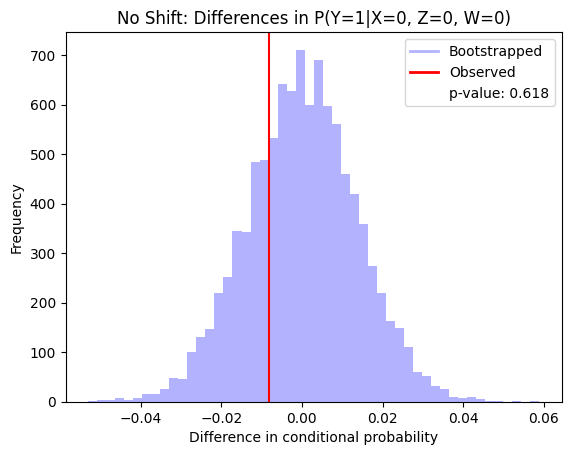

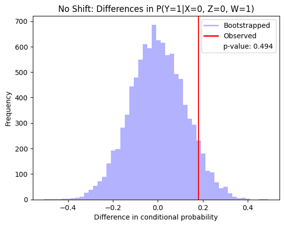

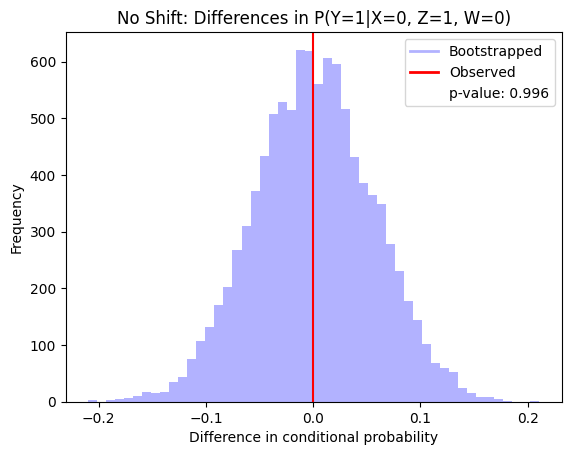

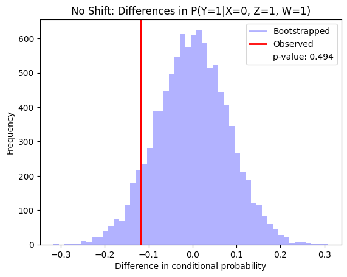

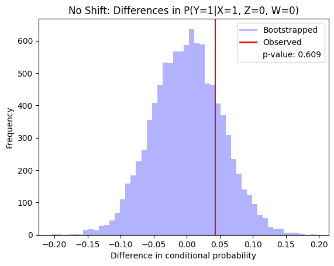

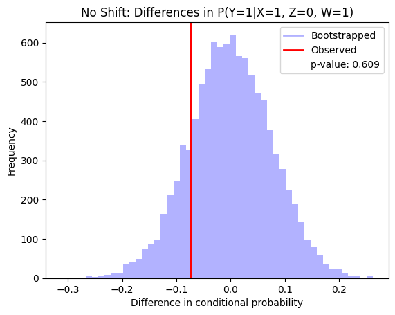

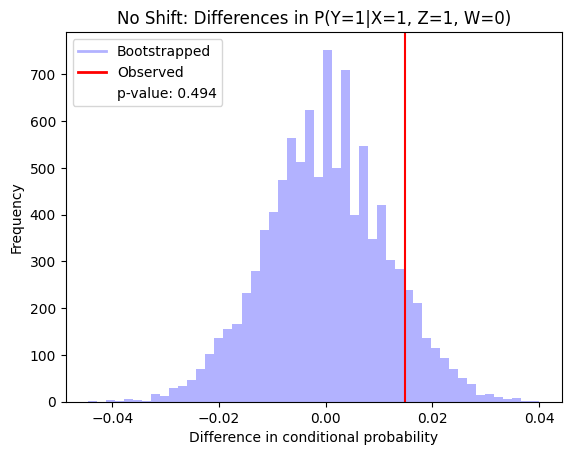

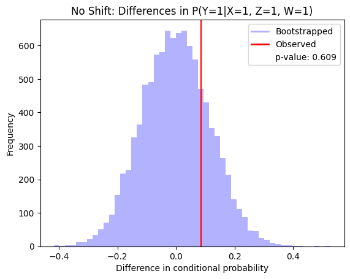

```python
#Histogram of bootstrapped differences for each tested conditional probability
for i in range(8):
    plt.hist(bootstrapped_diff_sample_1_sample_2[i], bins=50, alpha=0.3, label='Bootstrapped', color='blue')
    plt.axvline(y_conditional_difference_sample_1_sample_2['Difference'].values[i], color='red', label='Observed')
    plt.title(f'No Shift: Differences in P(Y=1|X={y_conditional_difference_sample_1_sample_2["X"].values[i]}, Z={y_conditional_difference_sample_1_sample_2["Z"].values[i]}, W={y_conditional_difference_sample_1_sample_2["W"].values[i]})')
    plt.xlabel('Difference in conditional probability')
    plt.ylabel('Frequency')
    # Create a legend without the p-value as a color-coded entry
    handles = [plt.Line2D([0], [0], color='blue',alpha = 0.3, lw=2, label='Bootstrapped'),
               plt.Line2D([0], [0], color='red', lw=2, label='Observed')]

    # Add the p-value as a plain text
    plt.legend(handles=handles + [plt.Line2D([0], [0], color='none', label=f'p-value: {bh_p_values_sample_1_sample_2[i]:.3f}')])
    plt.show()
```

For sample 1 vs sample 2, the p-values for the differences in conditional probabilities of $Y=1$ given $X,Z,W$ are all greater than $0.05$, indicating that the differences are not statistically significant. This is consistent with the fact that they are generated from the same SCM. As this holds for all individual $P(Y=1|X,Z,W)$ we would conclude that we cannot detect a statistically significant distribution shift between the two samples with respect to the conditional probability of Y.

We now examine the results for sample 1 vs sample 3. Given that they are generated from different SCMs we would expect to see at least one significant difference. Looking at the two different SCMs a bit more closely, we realistically should expect all individual differences to be significant as the SCMs differ such that each individual conditional is affected by the shift.

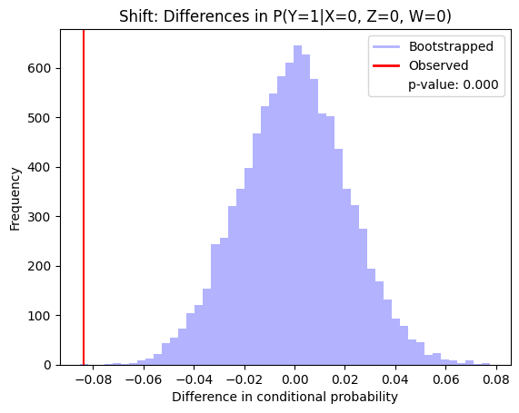

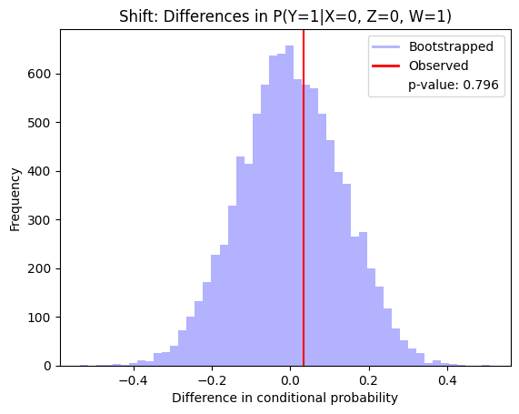

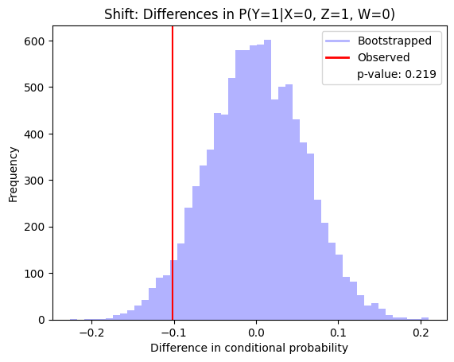

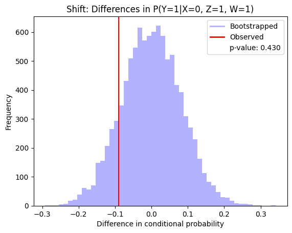

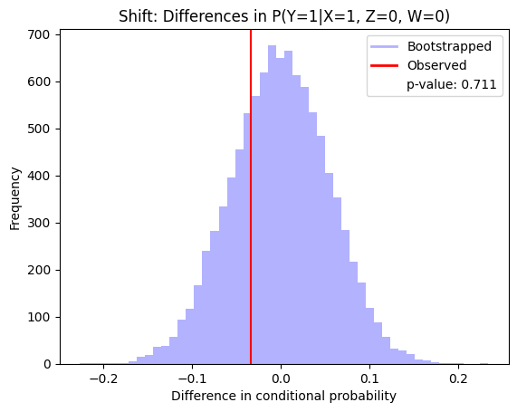

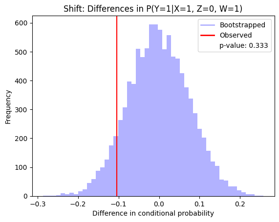

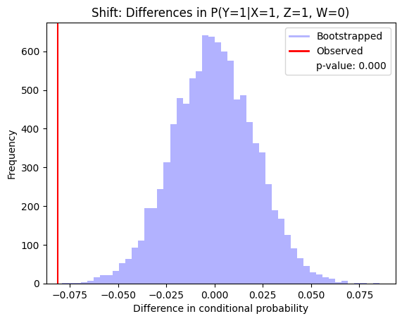

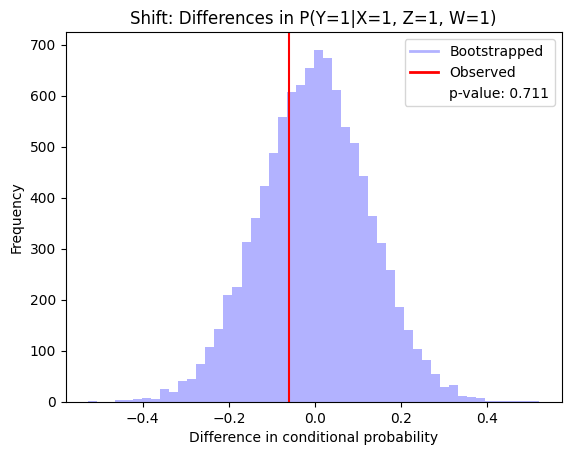

```python
#Histogram of bootstrapped differences for each tested conditional probability
for i in range(8):
    plt.hist(bootstrapped_diff_sample_1_sample_3[i], bins=50, alpha=0.3, label='Bootstrapped', color='blue')
    plt.axvline(y_conditional_difference_sample_1_sample_3['Difference'].values[i], color='red', label='Observed')
    plt.title(f'Shift: Differences in P(Y=1|X={y_conditional_difference_sample_1_sample_3["X"].values[i]}, Z={y_conditional_difference_sample_1_sample_3["Z"].values[i]}, W={y_conditional_difference_sample_1_sample_3["W"].values[i]})')
    plt.xlabel('Difference in conditional probability')
    plt.ylabel('Frequency')
    # Create a legend without the p-value as a color-coded entry
    handles = [plt.Line2D([0], [0], color='blue',alpha = 0.3, lw=2, label='Bootstrapped'),
               plt.Line2D([0], [0], color='red', lw=2, label='Observed')]

    # Add the p-value as a plain text
    plt.legend(handles=handles + [plt.Line2D([0], [0], color='none', label=f'p-value: {bh_p_values_sample_1_sample_3[i]:.3f}')])
    plt.show()
```

```python
print(f"The unadjusted p-values for sample 1 vs sample 3 are:\n{np.round(p_values_sample_1_sample_3,2)}\n")
```

```
The unadjusted p-values for sample 1 vs sample 3 are:
[0.   0.8  0.08 0.27 0.55 0.17 0.   0.62]
```

However, following the unadjusted p-values would also lead to the same decisions. A possible reason for the low power could also be that sampling variation dominates the distribution shift between sample 1 and sample 3 such that their difference is not detectable using the bootstrap test. The magnitude of shift between SCMs can be quantified exactly in this case and is given by  
\begin{align*} d = P_{s_1}(Y=1|X,Z,W) - P_{s_3}(Y=1|X,Z,W) = 0.09 \end{align*} We now repeat the test of sample 1 vs sample 3, but we change the following parameter:

- we change the SCMs such that we have a stronger shift of 0.5 and perform the test on the original sample size
- we keep the original SCMs and perform the test with increasing sample sizes [10,000;25,000;50,000]

```python
#Draw new sample 3 with d = 0.4
_ , sample_3_high_d = hiring_data(1, d=0.5)
#compute observed difference in conditionals between sample 1 and sample 3 with d = 0.4
y_conditional_diff_sample_1_sample_3_high_d = sample_1.groupby(['X','Z','W'])['Y'].mean().reset_index()['Y'].values - sample_3_high_d.groupby(['X','Z','W'])['Y'].mean().reset_index()['Y'].values

#Draw samples 1 and 2 with increasing sample sizes (n=1000, 10000, 25000, 50000)
sample_1_10000, sample_3_10000 = hiring_data(1,n=10000)
#compute observed difference in conditionals between sample 1 and sample 3 with n=10000
y_conditional_diff_sample_1_sample_3_10000 = sample_1_10000.groupby(['X','Z','W'])['Y'].mean().reset_index()['Y'].values - sample_3_10000.groupby(['X','Z','W'])['Y'].mean().reset_index()['Y'].values
sample_1_25000, sample_3_25000 = hiring_data(1,n=25000)
#compute observed difference in conditionals between sample 1 and sample 3 with n=25000
y_conditional_diff_sample_1_sample_3_25000 = sample_1_25000.groupby(['X','Z','W'])['Y'].mean().reset_index()['Y'].values - sample_3_25000.groupby(['X','Z','W'])['Y'].mean().reset_index()['Y'].values
sample_1_50000, sample_3_50000 = hiring_data(1,n=50000)
#compute observed difference in conditionals between sample 1 and sample 3 with n=50000
y_conditional_diff_sample_1_sample_3_50000 = sample_1_50000.groupby(['X','Z','W'])['Y'].mean().reset_index()['Y'].values - sample_3_50000.groupby(['X','Z','W'])['Y'].mean().reset_index()['Y'].values

#Perform bootstrap test for sample 1 vs sample 3 with d = 0.4
bootstrapped_diff_sample_1_sample_3_high_d, p_values_sample_1_sample_3_high_d, bh_p_values_sample_1_sample_3_high_d = bootstrap_test(sample_1, sample_3_high_d)

#Perform bootstrap test for sample 1 vs sample 2 with increasing sample sizes
bootstrapped_diff_sample_1_sample_3_10000, p_values_sample_1_sample_3_10000, bh_p_values_sample_1_sample_3_10000 = bootstrap_test(sample_1_10000, sample_3_10000)
bootstrapped_diff_sample_1_sample_3_25000, p_values_sample_1_sample_3_25000, bh_p_values_sample_1_sample_3_25000 = bootstrap_test(sample_1_25000, sample_3_25000)
bootstrapped_diff_sample_1_sample_3_50000, p_values_sample_1_sample_3_50000, bh_p_values_sample_1_sample_3_50000 = bootstrap_test(sample_1_50000, sample_3_50000)
```

Again, we visually inspect the tests.

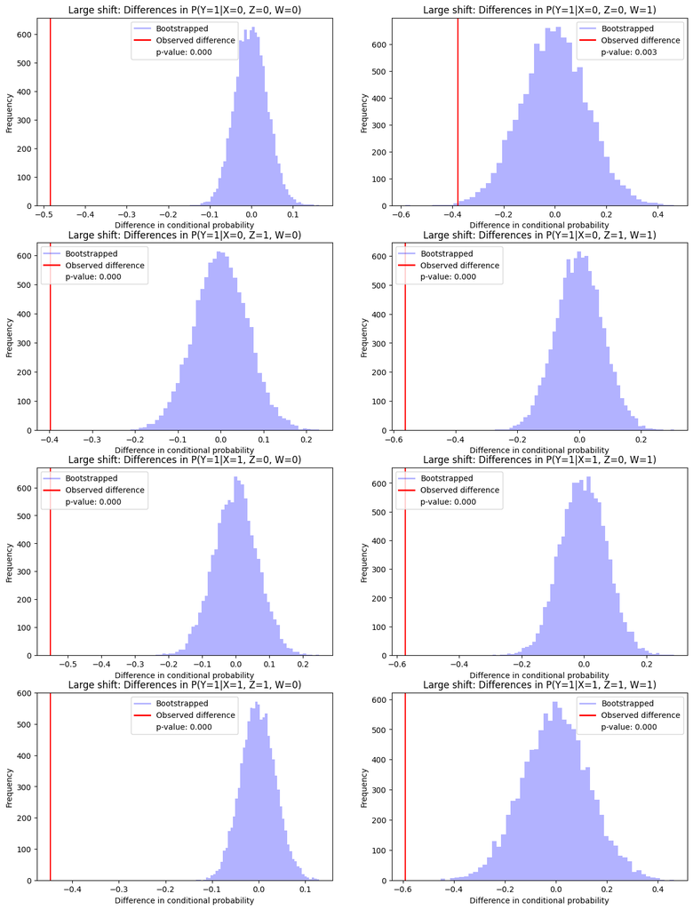

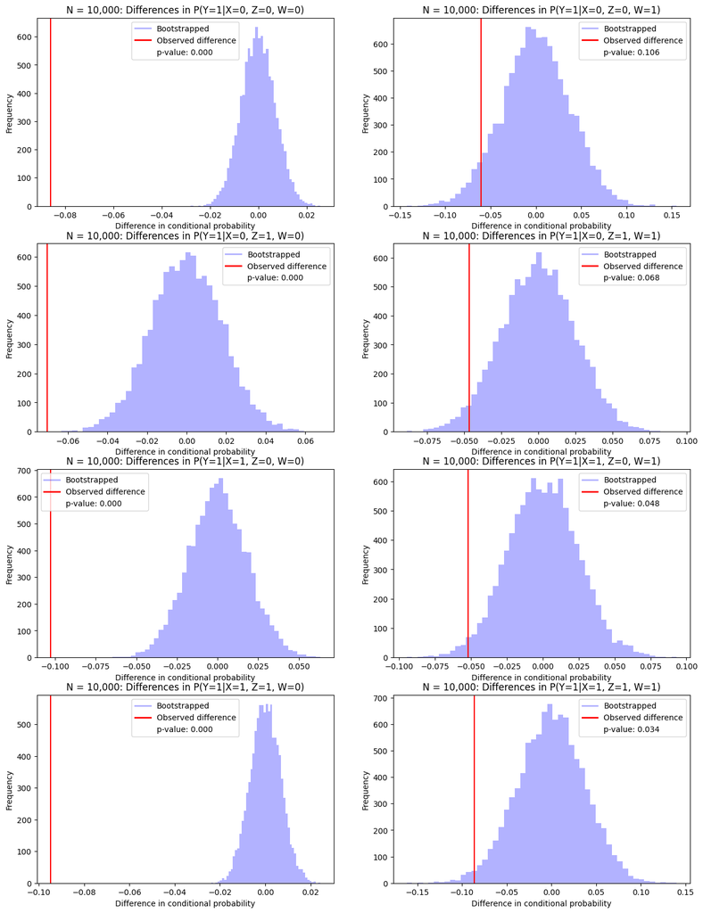

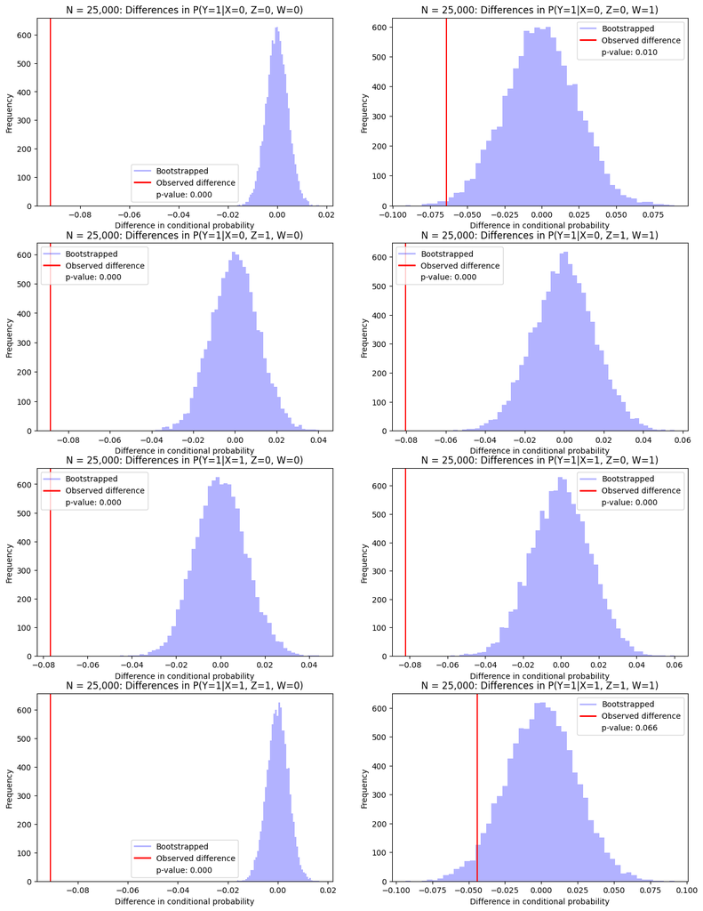

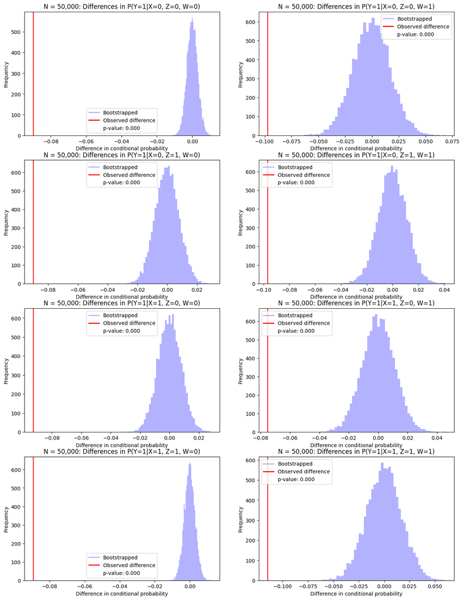

```python
#Plot histograms for each of the tests performed:
## Sample 1 vs Sample 3 with d = 0.4
fig, axs = plt.subplots(4, 2, figsize=(15, 20))
for i in range(8):
    ax = axs[i//2, i%2]
    ax.hist(bootstrapped_diff_sample_1_sample_3_high_d[i], bins=50, alpha=0.3, label='Bootstrapped', color='blue')
    ax.axvline(y_conditional_diff_sample_1_sample_3_high_d[i], color='red', label='Observed')
    ax.set_title(f'Large shift: Differences in P(Y=1|X={y_conditional_difference_sample_1_sample_3["X"].values[i]}, Z={y_conditional_difference_sample_1_sample_3["Z"].values[i]}, W={y_conditional_difference_sample_1_sample_3["W"].values[i]})')
    ax.set_xlabel('Difference in conditional probability')
    ax.set_ylabel('Frequency')
    # Create a legend without the p-value as a color-coded entry
    handles = [plt.Line2D([0], [0], color='blue',alpha = 0.3, lw=2, label='Bootstrapped'),
               plt.Line2D([0], [0], color='red', lw=2, label='Observed')]

    # Add the p-value as a plain text
    ax.legend(handles=handles + [plt.Line2D([0], [0], color='none', label=f'p-value: {bh_p_values_sample_1_sample_3_high_d[i]:.3f}')])

## Sample 1 vs Sample 2 with increasing sample sizes
##sample size 10000
fig, axs = plt.subplots(4, 2, figsize=(15, 20))

for i in range(8):
    ax = axs[i//2, i%2]
    ax.hist(bootstrapped_diff_sample_1_sample_3_10000[i], bins=50, alpha=0.3, label='Bootstrapped', color='blue')
    ax.axvline(y_conditional_diff_sample_1_sample_3_10000[i], color='red', label='Observed')
    ax.set_title(f'N = 10,000: Differences in P(Y=1|X={y_conditional_difference_sample_1_sample_2["X"].values[i]}, Z={y_conditional_difference_sample_1_sample_2["Z"].values[i]}, W={y_conditional_difference_sample_1_sample_2["W"].values[i]})')
    ax.set_xlabel('Difference in conditional probability')
    ax.set_ylabel('Frequency')
    # Create a legend without the p-value as a color-coded entry
    handles = [plt.Line2D([0], [0], color='blue',alpha = 0.3, lw=2, label='Bootstrapped'),
               plt.Line2D([0], [0], color='red', lw=2, label='Observed')]

    # Add the p-value as a plain text
    ax.legend(handles=handles + [plt.Line2D([0], [0], color='none', label=f'p-value: {bh_p_values_sample_1_sample_3_10000[i]:.3f}')])

##sample size 25000
fig, axs = plt.subplots(4, 2, figsize=(15, 20))

for i in range(8):
    ax = axs[i//2, i%2]
    ax.hist(bootstrapped_diff_sample_1_sample_3_25000[i], bins=50, alpha=0.3, label='Bootstrapped', color='blue')
    ax.axvline(y_conditional_diff_sample_1_sample_3_25000[i], color='red', label='Observed')
    ax.set_title(f'N = 25,000: Differences in P(Y=1|X={y_conditional_difference_sample_1_sample_2["X"].values[i]}, Z={y_conditional_difference_sample_1_sample_2["Z"].values[i]}, W={y_conditional_difference_sample_1_sample_2["W"].values[i]})')
    ax.set_xlabel('Difference in conditional probability')
    ax.set_ylabel('Frequency')
    # Create a legend without the p-value as a color-coded entry
    handles = [plt.Line2D([0], [0], color='blue',alpha = 0.3, lw=2, label='Bootstrapped'),
               plt.Line2D([0], [0], color='red', lw=2, label='Observed')]

    # Add the p-value as a plain text
    ax.legend(handles=handles + [plt.Line2D([0], [0], color='none', label=f'p-value: {bh_p_values_sample_1_sample_3_25000[i]:.3f}')])

##sample size 50000
fig, axs = plt.subplots(4, 2, figsize=(15, 20))

for i in range(8):
    ax = axs[i//2, i%2]
    ax.hist(bootstrapped_diff_sample_1_sample_3_50000[i], bins=50, alpha=0.3, label='Bootstrapped', color='blue')
    ax.axvline(y_conditional_diff_sample_1_sample_3_50000[i], color='red', label='Observed')
    ax.set_title(f'N = 50,000: Differences in P(Y=1|X={y_conditional_difference_sample_1_sample_2["X"].values[i]}, Z={y_conditional_difference_sample_1_sample_2["Z"].values[i]}, W={y_conditional_difference_sample_1_sample_2["W"].values[i]})')
    ax.set_xlabel('Difference in conditional probability')
    ax.set_ylabel('Frequency')
    # Create a legend without the p-value as a color-coded entry
    handles = [plt.Line2D([0], [0], color='blue',alpha = 0.3, lw=2, label='Bootstrapped'),
               plt.Line2D([0], [0], color='red', lw=2, label='Observed')]

    # Add the p-value as a plain text
    ax.legend(handles=handles + [plt.Line2D([0], [0], color='none', label=f'p-value: {bh_p_values_sample_1_sample_3_50000[i]:.3f}')])
```

For a very strong shift in distribution (i.e. $P(Y=1|X,Z,W)$ having difference $d = 0.5$), the bootstrap is capable of detecting any of the 8 individual conditionals as shifted. Thus, it seems that for more pronounced shifts the bootstrap tests becomes more powerful in detecting more fine-grained shifts instead of only detecting shifts on an aggregate level.

These two observations are important considerations, when choosing an appropiate method to detect dataset shifts. While in our example, the bootstrap test did not commit any Type I error, it was not able to detect all individual significant shifts. As the unadjusted p-values showed, it was not due to the more conservative decisions when correcting for multiple testing. Instead, lower sample sizes and less pronounced shifts seem to have a negative influence on its power. A more theoretical power analysis could shed more light into this, but is beyond the scope of this work.

Remembering the initial problem, we were interested whether the two samples coincide in the conditional of $Y$ on $X,Z,W$. We did this by restructuring the problem into testing whether the conditional means of Y differ between the samples as in this case: \begin{align*} \text{E}[Y|X,Z,W] = P(Y=1|X,Z,W) \end{align*}

However, there are also methods that can directly access the hypothesis, whether the two conditional distributions differ without requiring resampling methods. For instance, the $\Chi^2$-Test, which is recommended by [Rabanser, Günneman and Liption (2019)](https://proceedings.neurips.cc/paper/2019/hash/846c260d715e5b854ffad5f70a516c88-Abstract.html) for dataset shifts in case of categorical data.

We can perform the test as follows: \begin{align*} \text{} \quad & \textbf{Chi-squared test} \ \\ \text{} \quad & \textbf{Input:} \ \text{samples a and b and observational distributions} P_a(V) \text{ and } P_b(V)\\ \text{} \quad & \textbf{Output:} \ \text{array of Chi-squared statistics, array of p-values} \\ \text{} \quad & \\ \text{1.} \quad & \text{for all combinations of } X,Z,W \text{ do} \\ \text{2.} \quad & \quad \text{compute and store counts of } Y=0 \text{ and } Y=1 \\ \text{3.} \quad & \text{Merge the contigency tables for both samples} \\ \text{4.} \quad & \text{for all combinations of } X,Z,W \text{ do}\\ \text{5.} \quad & \quad \text{Perform Chi-Squared test and obtain statistic and p-value (i.e. using Scipy implementation)}\\ \end{align*}

While we are overall interested in whether the conditional distribution of Y differs between samples, the $\Chi^2$-Test frames the hypotheses as: \begin{align*} H_0: \text{Group (sample) membership is independent of Y for each (X,Z,W) \quad vs\quad} H_1: \text{Group (sample) membership is not independent of Y for each (X,Z,W)} \end{align*} The phrasing might sound confusing at first. But, the null essentially conveyes that if we compare the outcome of $Y$ between the two samples (groups), if their conditional on (X,Z,W) is the same, their distribution should not depend on whether the outcome comes from sample 1 or sample 2. If they are not the same, we would expect their distribution to differ depending on belonging to sample 1 or sample 2 which is formulated in the alternative.

Again, we have to break down the problem into performing 8 individual tests and adjust the p-values using Benjamini-Hochberg correction.

```python
#Chi-squared test to compare the distribution of Y=1 given X,Z,W between samples

def chi_squared_test(sample_a, sample_b):

    '''
    Function to perform chi-squared test for difference in distribution of Y=1 given X,Z,W for two samples

    Parameters:

    sample_a: pandas DataFrame containing sample A
    sample_b: pandas DataFrame containing sample B

    Returns:

    chi_squared_stats: numpy array containing chi-squared statistics for each tested conditional probability
    p_values: numpy array for the individual hypothesis tests
    adjusted_p_values: numpy array for the adjusted p-values using Benjamini-Hochberg
    '''

    #compute counts of Y=1 and Y=0 for each combination of X,Z,W for both samples
    y_counts_sample_a = sample_a.groupby(['X','Z','W'])['Y'].value_counts().unstack().reset_index().fillna(0)
    y_counts_sample_b = sample_b.groupby(['X','Z','W'])['Y'].value_counts().unstack().reset_index().fillna(0)
    #merge the two contingency tables
    merged_counts = pd.merge(y_counts_sample_a, y_counts_sample_b, on=['X', 'Z', 'W'], suffixes=('_s1', '_s2'))
    #empty arrays to store chi-squared statistics and p-values
    chi_squared_stats = np.empty(8)
    p_values = np.zeros(8)
    #loop through each combination of X,Z,W
    for i, row in merged_counts.iterrows():
        #construct contingency table
        contingency_table = row[['0_s1', '1_s1', '0_s2', '1_s2']].values.reshape(2, 2)
        #perform chi-squared test
        chi2_stat, p_val, _, _ = chi2_contingency(contingency_table)
        chi_squared_stats[i] = chi2_stat
        p_values[i] = p_val

    #Need to adjust for multiple testing
    bh_p_values = multitest.multipletests(p_values, method='fdr_bh')[1]

    #return chi-squared statistics and p-values
    return chi_squared_stats, p_values, bh_p_values


#perform chi-squared test for sample 1 vs sample 2 and sample 1 vs sample 3
chi_squared_stats_sample_1_sample_2, p_values_chi_squared_sample_1_sample_2, bh_p_values_chi_squared_sample_1_sample_2 = chi_squared_test(sample_1, sample_2)
chi_squared_stats_sample_1_sample_3, p_values_chi_squared_sample_1_sample_3, bh_p_values_chi_squared_sample_1_sample_3 = chi_squared_test(sample_1, sample_3)

#Summarise results in a table
sample_1_sample_2_chi_squared_results = pd.DataFrame({'Chi-squared statistics': chi_squared_stats_sample_1_sample_2, 'p-values': p_values_chi_squared_sample_1_sample_2, 'Adjusted p-values': bh_p_values_chi_squared_sample_1_sample_2})
sample_1_sample_2_chi_squared_results.index = index

sample_1_sample_3_chi_squared_results = pd.DataFrame({'Chi-squared statistics': chi_squared_stats_sample_1_sample_3, 'p-values': p_values_chi_squared_sample_1_sample_3, 'Adjusted p-values': bh_p_values_chi_squared_sample_1_sample_3})
sample_1_sample_3_chi_squared_results.index = index
print(f"Chi-squared test results for sample 1 vs sample 2:\n\n{sample_1_sample_2_chi_squared_results}\n")
print(f"Chi-squared test results for sample 1 vs sample 3:\n\n{sample_1_sample_3_chi_squared_results}\n")
```

```
Chi-squared test results for sample 1 vs sample 2:

                    Chi-squared statistics  p-values  Adjusted p-values
P(Y=1|X=0,Z=0,W=0)                0.097909  0.754354           0.862119
P(Y=1|X=0,Z=0,W=1)                1.397975  0.237063           0.799374
P(Y=1|X=0,Z=1,W=0)                0.000000  1.000000           1.000000
P(Y=1|X=0,Z=1,W=1)                1.637481  0.200671           0.799374
P(Y=1|X=1,Z=0,W=0)                0.455767  0.499609           0.799374
P(Y=1|X=1,Z=0,W=1)                0.624470  0.429391           0.799374
P(Y=1|X=1,Z=1,W=0)                1.007113  0.315595           0.799374
P(Y=1|X=1,Z=1,W=1)                0.193966  0.659636           0.862119

Chi-squared test results for sample 1 vs sample 3:

                    Chi-squared statistics  p-values  Adjusted p-values
P(Y=1|X=0,Z=0,W=0)               13.997309  0.000183           0.001035
P(Y=1|X=0,Z=0,W=1)                0.000000  1.000000           1.000000
P(Y=1|X=0,Z=1,W=0)                2.569339  0.108953           0.290542
P(Y=1|X=0,Z=1,W=1)                0.898327  0.343231           0.549169
P(Y=1|X=1,Z=0,W=0)                0.212399  0.644894           0.859858
P(Y=1|X=1,Z=0,W=1)                1.386053  0.239073           0.478146
P(Y=1|X=1,Z=1,W=0)               13.347451  0.000259           0.001035
P(Y=1|X=1,Z=1,W=1)                0.042302  0.837046           0.956624
```

As before, we can repeat the test for increasing sample sizes. We will pay special attention to the individual sample sizes corresponding to each sub-problem. We begin by examining the individual sample sizes for the just performed test and then perform the test for increasing sample sizes again.

```python
#Track count of observations for each individual combination of X,Z,W
sample_1_counts = sample_1.groupby(['X','Z','W']).size().reset_index(name='Count')
sample_2_counts = sample_2.groupby(['X','Z','W']).size().reset_index(name='Count')
sample_3_counts = sample_3.groupby(['X','Z','W']).size().reset_index(name='Count')
#Merge all counts
merged_counts = sample_1_counts.merge(sample_2_counts, on=['X','Z','W'], suffixes=('_s1','_s2')).merge(sample_3_counts, on=['X','Z','W'])
merged_counts.columns = ['X','Z','W','Count_s1','Count_s2','Count_s3']
#Print
print(f"Counts of observations for each individual combination of X,Z,W for all samples:\n\n{merged_counts}\n")

#Perform test again for increasing sample sizes (only for sample 1 vs sample 3)
sample_1_n_10000, sample_3_n_10000 = hiring_data(1,n=10000)
sample_1_n_10000_counts, sample_3_n_10000_counts = sample_1_n_10000.groupby(['X','Z','W']).size().reset_index(name='Count'), sample_3_n_10000.groupby(['X','Z','W']).size().reset_index(name='Count')
merged_counts_n_10000 = sample_1_n_10000_counts.merge(sample_3_n_10000_counts, on=['X','Z','W'])
merged_counts_n_10000.columns = ['X','Z','W','Count_s1','Count_s3']
chi_squared_stats_sample_1_sample_3_n_10000, p_values_chi_squared_sample_1_sample_3_n_10000, bh_p_values_chi_squared_sample_1_sample_3_n_10000 = chi_squared_test(sample_1_n_10000, sample_3_n_10000)
merged_counts_n_10000['Adj. p-values'] = np.round(bh_p_values_chi_squared_sample_1_sample_3_n_10000,4)
print(f"Results for sample 1 vs sample 3 with N=10,000:\n\n{merged_counts_n_10000}\n")

sample_1_n_25000, sample_3_n_25000 = hiring_data(1,n=25000)
sample_1_n_25000_counts, sample_3_n_25000_counts = sample_1_n_25000.groupby(['X','Z','W']).size().reset_index(name='Count'), sample_3_n_25000.groupby(['X','Z','W']).size().reset_index(name='Count')
merged_counts_n_25000 = sample_1_n_25000_counts.merge(sample_3_n_25000_counts, on=['X','Z','W'])
merged_counts_n_25000.columns = ['X','Z','W','Count_s1','Count_s3']
chi_squared_stats_sample_1_sample_3_n_25000, p_values_chi_squared_sample_1_sample_3_n_25000, bh_p_values_chi_squared_sample_1_sample_3_n_25000 = chi_squared_test(sample_1_n_25000, sample_3_n_25000)
merged_counts_n_25000['Adj. p-values'] = np.round(bh_p_values_chi_squared_sample_1_sample_3_n_25000,4)
print(f"Results for sample 1 vs sample 3 with N=25,000:\n\n{merged_counts_n_25000}\n")

sample_1_n_50000, sample_3_n_50000 = hiring_data(1,n=50000)
sample_1_n_50000_counts, sample_3_n_50000_counts = sample_1_n_50000.groupby(['X','Z','W']).size().reset_index(name='Count'), sample_3_n_50000.groupby(['X','Z','W']).size().reset_index(name='Count')
merged_counts_n_50000 = sample_1_n_50000_counts.merge(sample_3_n_50000_counts, on=['X','Z','W'])
merged_counts_n_50000.columns = ['X','Z','W','Count_s1','Count_s3']
chi_squared_stats_sample_1_sample_3_n_50000, p_values_chi_squared_sample_1_sample_3_n_50000, bh_p_values_chi_squared_sample_1_sample_3_n_50000 = chi_squared_test(sample_1_n_50000, sample_3_n_50000)
merged_counts_n_50000['Adj. p-values'] = np.round(bh_p_values_chi_squared_sample_1_sample_3_n_50000,4)
print(f"Results for sample 1 vs sample 3 with N=50,000:\n\n{merged_counts_n_50000}\n")
```

```
Counts of observations for each individual combination of X,Z,W for all samples:

   X  Z  W  Count_s1  Count_s2  Count_s3
0  0  0  0       255       252       252
1  0  0  1        24        34        34
2  0  1  0       124       128       128
3  0  1  1        78        74        74
4  1  0  0       115       131       131
5  1  0  1       107        66        66
6  1  1  0       273       281       281
7  1  1  1        24        34        34

Results for sample 1 vs sample 3 with N=10,000:

   X  Z  W  Count_s1  Count_s3  Adj. p-values
0  0  0  0      2603      2658         0.0000
1  0  0  1       303       311         0.1252
2  0  1  0      1248      1184         0.0002
3  0  1  1       811       831         0.0737
4  1  0  0      1249      1220         0.0000
5  1  0  1       815       843         0.0511
6  1  1  0      2678      2641         0.0000
7  1  1  1       293       312         0.0452

Results for sample 1 vs sample 3 with N=25,000:

   X  Z  W  Count_s1  Count_s3  Adj. p-values
0  0  0  0      6691      6677         0.0000
1  0  0  1       702       746         0.0115
2  0  1  0      3002      3081         0.0000
3  0  1  1      2070      2030         0.0000
4  1  0  0      3078      3043         0.0000
5  1  0  1      2075      2097         0.0000
6  1  1  0      6604      6623         0.0000
7  1  1  1       778       703         0.0738

Results for sample 1 vs sample 3 with N=50,000:

   X  Z  W  Count_s1  Count_s3  Adj. p-values
0  0  0  0     13353     13124            0.0
1  0  0  1      1432      1426            0.0
2  0  1  0      6112      6210            0.0
3  0  1  1      4127      4128            0.0
4  1  0  0      6154      6220            0.0
5  1  0  1      4114      4144            0.0
6  1  1  0     13236     13289            0.0
7  1  1  1      1472      1459            0.0
```

We can notice that for the original example (i.e. $N=1,000$), the two individual conditionals which our previous tests correctly identified as different where also the ones where the corresponding subproblem had the largest and 2nd largest samples size. As we increase the sample size, we can again see that the tests is able to detect each individual difference.

We can also run the test again with the same large shift of $d=0.50$ between sample 1 and sample 3.

```python
#Perform test again for sample 1 vs sample 3 with d = 0.5
chi_squared_stats_sample_1_sample_3_high_d, p_values_chi_squared_sample_1_sample_3_high_d, bh_p_values_chi_squared_sample_1_sample_3_high_d = chi_squared_test(sample_1, sample_3_high_d)
print(f"Chi-squared test results for sample 1 vs sample 3 with d = 0.4:\n\n{np.round(p_values_chi_squared_sample_1_sample_3_high_d,4)}\n")
```

```
Chi-squared test results for sample 1 vs sample 3 with d = 0.4:

[0.     0.0076 0.     0.     0.     0.     0.     0.    ]
```

As with the bootstrap, the $X^2$ test is able to detect all individual shifts if there is a more pronounced difference in the conditional of $Y$ between samples.

A preliminary summary so far could be that:

- Bootstrap and $X^2$-test do not reject the nulls when there is no shift between samples in the example.
- Bootstrap and $X^2$-test are able to detect shifts between samples from a aggregate perspective (detect at least 1 significant shift)
- However, testing individual conditionals leads to less rejections as one would expect. For moderate sample size and smaller shifts this might be an issue.
- This seems in part due to breaking down the testing problem into 8 individual ones as it strongly decreases the number of observations used for each individual test.
- For large enough samples, this does not seem to be a problem anymore.

We will continue by trying out 2 additional tests, before shifting our attention towards a more "non-traditional" approach. The 2 additional tests are:

- $Z$-test for proportions
- testing weighted outcomes as described in [Schrouff et al (2022)](https://proceedings.neurips.cc/paper_files/paper/2022/hash/7a969c30dc7e74d4e891c8ffb217cf79-Abstract-Conference.html)

We begin with the $Z$-test. First, we notice that even without knowing the underlying data-generating mechanism one could assume that each observation in a sample corresponds to the outcome of a Bernoulli-Trial. The sample then corresponds to a sequence of $N$ individual Bernoulli-trials, which can be modelled with a binomial distribution $Binomial(n,p)$, where n corresponds to the number of samples and p the probability of success.

For this example, we could assume the following for each individual observation and the overall sample: \begin{align*} Y_i \leftarrow Ber(p(X,W,Z))\\ Y \leftarrow Bin(n, p(X,W,Z)) \end{align*}

where, we assume that for both the individual observation and the overall sample the probability/number of successes for $Y$ depends on $X,W,Z$. For the probability of success, we can simply compute the empirical probability of success for all specific combinations of $(X,W,Z)$, while taking the number of samples available for that combination as our $n$. Thus, we model the conditional of $Y$ as: \begin{align*} Y=1 | X=x, W=w, Z=z \leftarrow \text{Bin}(n_{xwz}, \hat{p}(x,w,z)) \end{align*}

Further, we could also try a Normal approxmiation to the Binomial. Let's begin by first computing the individual $\hat{p}(x,w,z)$ and $n_{xwz}$.

```python
#Bernoulli Trial
##compute p of success conditionally on X,Z,W for all samples
p_conditional_on_xzw_sample_1 = sample_1.groupby(['X','Z','W'])['Y'].mean().reset_index()['Y'].values
p_conditional_on_xzw_sample_2 = sample_2.groupby(['X','Z','W'])['Y'].mean().reset_index()['Y'].values
p_conditional_on_xzw_sample_3 = sample_3.groupby(['X','Z','W'])['Y'].mean().reset_index()['Y'].values

#Binomial Distribution
##compute number of samples for each combination of X,Z,W for all samples
n_sample_1 = sample_1.groupby(['X','Z','W']).size().reset_index(name='Count')['Count'].values
n_sample_2 = sample_2.groupby(['X','Z','W']).size().reset_index(name='Count')['Count'].values
n_sample_3 = sample_3.groupby(['X','Z','W']).size().reset_index(name='Count')['Count'].values
```

Using that we can perform a Z-test to test \begin{align*} H_{0}: P_{s_1}(Y|X,Z,W) &= P_{s_2}(Y|X,Z,W)\quad \text{vs} \quad H_{1}: P_{s_1}(Y|X,Z,W) \neq P_{s_2}(Y|X,Z,W)\\ H_{0}: P_{s_1}(Y|X,Z,W) &= P_{s_3}(Y|X,Z,W)\quad \text{vs} \quad H_{1}: P_{s_1}(Y|X,Z,W) \neq P_{s_3}(Y|X,Z,W)\\ \end{align*} by asessing the following hypotheses: \begin{align*} H_{0}: \hat{p}_{s_1}(x,w,z) &- \hat{p}_{s_2}(x,w,z) = 0\quad \text{vs} \quad H_{1}: \hat{p}_{s_1}(x,w,z) - \hat{p}_{s_2}(x,w,z) \neq 0\\ H_{0}: \hat{p}_{s_1}(x,w,z) &- \hat{p}_{s_3}(x,w,z) = 0\quad \text{vs} \quad H_{1}: \hat{p}_{s_1}(x,w,z) - \hat{p}_{s_3}(x,w,z) \neq 0\\ \end{align*}

In case of no shift, the difference between the sample proportions should not be significantly different from each other while the opposite should hold in presence of distribution shifts. We will perform two slightly different versions of the test. The first is the "standard" approach and is given by: \begin{align*} \text{} \quad & \textbf{Z-test for proportions} \ \\ \text{} \quad & \textbf{Input:} \ \text{samples a and b and observational distributions} P_a(V) \text{ and } P_b(V)\\ \text{} \quad & \textbf{Output:} \ \text{array of p-values} \\ \text{} \quad & \\ \text{1.} \quad & \text{for both samples: }\text{ do} \\ \text{2.} \quad & \quad \text{Compute and store: } \hat{p}(Y=1|x,z,w) \text{ and }n_{xwz} \\ \text{3.} \quad & \text{Compute } d=\hat{p}_a(Y=1|x,z,w) - \hat{p}_b(Y=1|x,z,w) \\ \text{4.} \quad & \text{Compute } p^{pool} = \frac{n_{a_{xwz}}*\hat{p}_a(Y=1|x,z,w) + n_{b_{xwz}}*\hat{p}_b(Y=1|x,z,w)}{n_{a_{xwz}} + n_{b_{xwz}}} \\ \text{5.} \quad & \text{Compute the test statistic } z = \frac{d}{\sqrt{p^{pool}(1-p^{pool})(\frac{1}{n_{a_{xwz}}}+\frac{1}{n_{b_{xwz}}})}} \\ \text{6.} \quad & \text{Obtain p-values by } p = 2(1 − Φ(|z|), \text{where Φ(|z|) is the CDF of the standard Normal distribution.}\\ \end{align*}

```python
#Perform the z-test for proportions for sample 1 vs sample 2 and sample 1 vs sample 3

def z_test(sample_a, sample_b):

    '''
    Function to perform z-test for difference in conditional probabilities of Y=1 given X,Z,W for two samples

    Parameters:

    sample_a: pandas DataFrame containing sample A
    sample_b: pandas DataFrame containing sample B

    Returns:

    z: numpy array containing z-statistics for each tested conditional probability
    p_values: numpy array for the individual hypothesis tests
    adjusted_p_values: numpy array for the adjusted p-values using Benjamini-Hochberg
    '''

    #compute empirircal probabilities of success and number of samples for each combination of X,Z,W for both samples
    p_sample_a = sample_a.groupby(['X','Z','W'])['Y'].mean().reset_index()['Y'].values
    n_sample_a = sample_a.groupby(['X','Z','W']).size().reset_index(name='Count')['Count'].values
    p_sample_b = sample_b.groupby(['X','Z','W'])['Y'].mean().reset_index()['Y'].values
    n_sample_b = sample_b.groupby(['X','Z','W']).size().reset_index(name='Count')['Count'].values
    #compute pooled p
    p_pooled = (p_sample_a*n_sample_a + p_sample_b*n_sample_b)/(n_sample_a + n_sample_b)
    #compute test statistic z
    z = (p_sample_a - p_sample_b)/np.sqrt(p_pooled*(1-p_pooled)*(1/n_sample_a + 1/n_sample_b))
    #compute p-values
    p_values = 2*(1-norm.cdf(np.abs(z)))
    #Need to adjust for multiple testing
    bh_p_values = multitest.multipletests(p_values, method='fdr_bh')[1]

    #return z-statistics and p-values
    return z, p_values, bh_p_values


#perform z-test for sample 1 vs sample 2 and sample 1 vs sample 3
z_stats_sample_1_sample_2, p_values_z_sample_1_sample_2, bh_p_values_z_sample_1_sample_2 = z_test(sample_1, sample_2)
z_stats_sample_1_sample_3, p_values_z_sample_1_sample_3, bh_p_values_z_sample_1_sample_3 = z_test(sample_1, sample_3)

#Summarise results in a table
sample_1_sample_2_z_results = pd.DataFrame({'Z statistics': z_stats_sample_1_sample_2, 'p-values': p_values_z_sample_1_sample_2, 'Adjusted p-values': bh_p_values_z_sample_1_sample_2})
sample_1_sample_2_z_results.index = index
sample_1_sample_3_z_results = pd.DataFrame({'Z statistics': z_stats_sample_1_sample_3, 'p-values': p_values_z_sample_1_sample_3, 'Adjusted p-values': bh_p_values_z_sample_1_sample_3})
sample_1_sample_3_z_results.index = index

#Print results
print(f"Z-test results for sample 1 vs sample 2:\n\n{sample_1_sample_2_z_results}\n")
print(f"Z-test results for sample 1 vs sample 3:\n\n{sample_1_sample_3_z_results}\n")
```

```
Z-test results for sample 1 vs sample 2:

                    Z statistics  p-values  Adjusted p-values
P(Y=1|X=0,Z=0,W=0)     -0.605062  0.545138           0.623015
P(Y=1|X=0,Z=0,W=1)      1.470498  0.141427           0.495823
P(Y=1|X=0,Z=1,W=0)      0.004572  0.996352           0.996352
P(Y=1|X=0,Z=1,W=1)     -1.442271  0.149226           0.495823
P(Y=1|X=1,Z=0,W=0)      0.833878  0.404350           0.602792
P(Y=1|X=1,Z=0,W=1)     -0.947916  0.343172           0.602792
P(Y=1|X=1,Z=1,W=0)      1.322705  0.185934           0.495823
P(Y=1|X=1,Z=1,W=1)      0.751929  0.452094           0.602792

Z-test results for sample 1 vs sample 3:

                    Z statistics  p-values  Adjusted p-values
P(Y=1|X=0,Z=0,W=0)     -3.926663  0.000086           0.000526
P(Y=1|X=0,Z=0,W=1)      0.263105  0.792470           0.792470
P(Y=1|X=0,Z=1,W=0)     -1.739196  0.082000           0.218667
P(Y=1|X=0,Z=1,W=1)     -1.110772  0.266667           0.426667
P(Y=1|X=1,Z=0,W=0)     -0.609651  0.542093           0.713539
P(Y=1|X=1,Z=0,W=1)     -1.334585  0.182012           0.364025
P(Y=1|X=1,Z=1,W=0)     -3.823614  0.000132           0.000526
P(Y=1|X=1,Z=1,W=1)     -0.489700  0.624346           0.713539
```

Essentially, the performance is in line with all of the previously done tests. If there is no shift, the tests correctly recognizes that. While for a shift with magnitude $d=0.09$ it is only able to detect $\frac{2}{8}=25%$ of all individual shifts. As in real-life, we would only observe $P(X,W,Z,Y)$ without knowing the underlying SCM, the test would still correctly indicate that there is a shift from an aggregate perspective. For more pronounced shifts ($d=0.50$) and larger sample sizes, we would expect the test's power with respect to the individual conditionals to improve as it did with the previous methods. Thus, we will in this case not run the test again with larger shifts and samples (Might be in an appendix).

The z-test is parametric in the sense that assumes that the sampling distribution for the difference in proportions is approximately normal. Instead of only relying on our two available samples, we could also try to bootstrap the whole procedure by: \begin{align*} \text{} \quad & \textbf{Bootstrapped Z-test for proportions} \ \\ \text{} \quad & \textbf{Input:} \ \text{samples a and b and observational distributions} P_a(V) \text{ and } P_b(V)\\ \text{} \quad & \textbf{Output:} \ \text{array of (bootstrapped) Z statistics, array of p-values} \\ \text{} \quad & \\ \text{1.} \quad & \text{for both samples }\text{ do:} \\ \text{2.} \quad & \quad \text{Compute and store: } \hat{p}(Y=1|x,z,w) \text{ and }n_{xwz} \\ \text{3.} \quad & \text{Compute } d=\hat{p}_a(Y=1|x,z,w) - \hat{p}_b(Y=1|x,z,w) \\ \text{4.} \quad & \text{Compute } p^{pool} = \frac{n_{a_{xwz}}*\hat{p}_a(Y=1|x,z,w) + n_{b_{xwz}}*\hat{p}_b(Y=1|x,z,w)}{n_{a_{xwz}} + n_{b_{xwz}}} \\ \text{5.} \quad & \text{Compute the test statistic } z = \frac{d}{\sqrt{p^{pool}(1-p^{pool})(\frac{1}{n_{a_{xwz}}}+\frac{1}{n_{b_{xwz}}})}} \\ \text{6.} \quad & \text{For } i:n_{boot}\text{\quad do:} \\ \text{7.} \quad & \quad \text{Pool samples a and b}\\ \text{8.} \quad & \quad \text{draw samples } a^{boot} \text{ and } b^{boot} \text{ from pooled sample with replacement}\\ \text{9.} \quad & \quad \text{for } a^{boot}, b^{boot}\text{ do:} \\ \text{10.} \quad & \quad \quad \text{repeat steps 2-5} \\ \text{11.} \quad & \text{Compute p-values } p=\frac{\#\{|z^{boot} \geq z|\}}{n_{boot}} \\ \end{align*}

We again assume exchangeability between samples under the null. Thus, we pool the samples again. The $z$-statistic is then bootstrapped under the null. We then compute the proportion of $z^{boot}$ which is at least as extreme as our observed $z$. The rationale is to compare how likely it is to obtain a $z$-statistic in the magnitude of the observed one assuming the null is true.

```python
B = 10000

#empty arrays to store bootstrapped z-statistics
bootstrap_z_stats_sample_1_sample_2 = np.empty((8,B))
bootstrap_z_stats_sample_1_sample_3 = np.empty((8,B))



#loop through B iterations
for i in tqdm.tqdm(range(B), desc='Bootstrapping'):

    #sample 1 vs sample 2
    ##pool the samples
    pooled_bootstrap_sample = pd.concat([sample_1, sample_2])
    #shuffle pooled data
    bootstrap_sample = pooled_bootstrap_sample.sample(n=len(pooled_bootstrap_sample), replace=True)
    #create bootstrap samples
    bootstrap_sample_1 = bootstrap_sample.iloc[:len(sample_1)]
    bootstrap_sample_2 = bootstrap_sample.iloc[len(sample_1):]
    #perform z-test
    bootstrap_z_stats_sample_1_sample_2[:,i],_,_ = z_test(bootstrap_sample_1, bootstrap_sample_2)

    #sample 1 vs sample 3
    ##pool the samples
    pooled_bootstrap_sample = pd.concat([sample_1, sample_3])
    #shuffle pooled data
    bootstrap_sample = pooled_bootstrap_sample.sample(n=len(pooled_bootstrap_sample), replace=True)
    #create bootstrap samples
    bootstrap_sample_1 = bootstrap_sample.iloc[:len(sample_1)]
    bootstrap_sample_3 = bootstrap_sample.iloc[len(sample_1):]
    #perform z-test
    bootstrap_z_stats_sample_1_sample_3[:,i],_,_ = z_test(bootstrap_sample_1, bootstrap_sample_3)

#compute p-vals
bootstrap_p_values_sample_1_sample_2 = np.zeros(8)
bootstrap_p_values_sample_1_sample_3 = np.zeros(8)

for i in range(8):
    bootstrap_p_values_sample_1_sample_2[i] = np.sum(np.abs(bootstrap_z_stats_sample_1_sample_2[i,:]) >= np.abs(z_stats_sample_1_sample_2[i]))/B
    bootstrap_p_values_sample_1_sample_3[i] = np.sum(np.abs(bootstrap_z_stats_sample_1_sample_3[i,:]) >= np.abs(z_stats_sample_1_sample_3[i]))/B

#adjust for multiple testing
bh_bootstrap_p_values_sample_1_sample_2 = multitest.multipletests(bootstrap_p_values_sample_1_sample_2, method='fdr_bh')[1]
bh_bootstrap_p_values_sample_1_sample_3 = multitest.multipletests(bootstrap_p_values_sample_1_sample_3, method='fdr_bh')[1]
```

After running the bootstrapped variant, we can inspect the results and p-values visually.

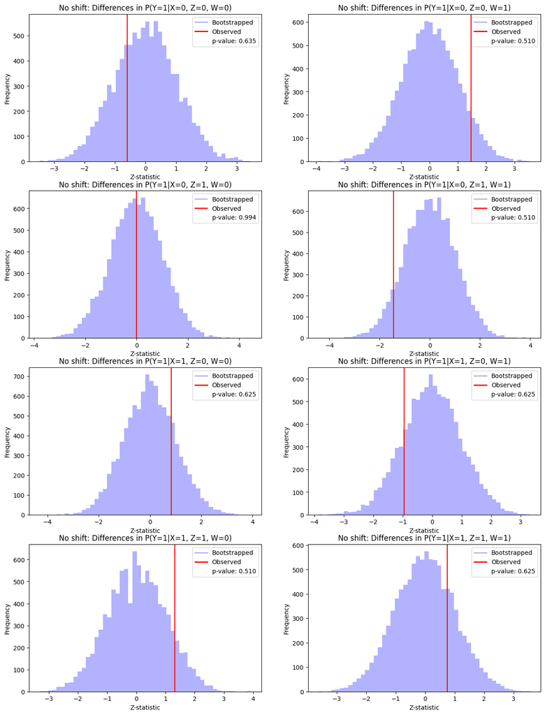

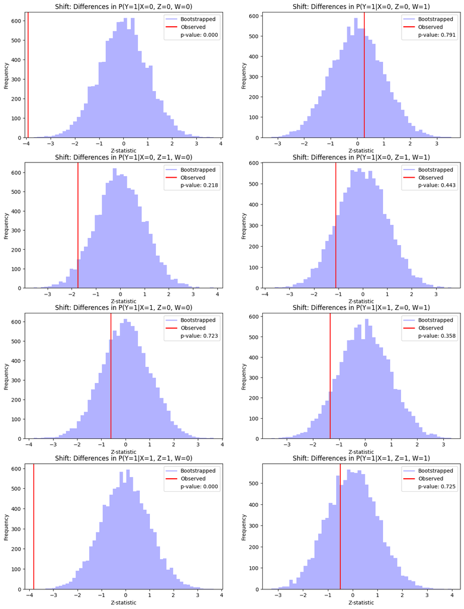

```python
#Sample 1 vs Sample 2
fig, axs = plt.subplots(4, 2, figsize=(15, 20))
for i in range(8):
    ax = axs[i//2, i%2]
    ax.hist(bootstrap_z_stats_sample_1_sample_2[i], bins=50, alpha=0.3, label='Bootstrapped', color='blue')
    ax.axvline(z_stats_sample_1_sample_2[i], color='red', label='Observed')
    ax.set_title(f'No shift: Differences in P(Y=1|X={y_conditional_difference_sample_1_sample_2["X"].values[i]}, Z={y_conditional_difference_sample_1_sample_2["Z"].values[i]}, W={y_conditional_difference_sample_1_sample_2["W"].values[i]})')
    ax.set_xlabel('Z-statistic')
    ax.set_ylabel('Frequency')
    # Create a legend without the p-value as a color-coded entry
    handles = [plt.Line2D([0], [0], color='blue',alpha = 0.3, lw=2, label='Bootstrapped'),
               plt.Line2D([0], [0], color='red', lw=2, label='Observed')]

    # Add the p-value as a plain text
    ax.legend(handles=handles + [plt.Line2D([0], [0], color='none', label=f'p-value: {bh_bootstrap_p_values_sample_1_sample_2[i]:.3f}')])

#Sample 1 vs Sample 3
fig, axs = plt.subplots(4, 2, figsize=(15, 20))
for i in range(8):
    ax = axs[i//2, i%2]
    ax.hist(bootstrap_z_stats_sample_1_sample_3[i], bins=50, alpha=0.3, label='Bootstrapped', color='blue')
    ax.axvline(z_stats_sample_1_sample_3[i], color='red', label='Observed')
    ax.set_title(f'Shift: Differences in P(Y=1|X={y_conditional_difference_sample_1_sample_3["X"].values[i]}, Z={y_conditional_difference_sample_1_sample_3["Z"].values[i]}, W={y_conditional_difference_sample_1_sample_3["W"].values[i]})')
    ax.set_xlabel('Z-statistic')
    ax.set_ylabel('Frequency')
    # Create a legend without the p-value as a color-coded entry
    handles = [plt.Line2D([0], [0], color='blue',alpha = 0.3, lw=2, label='Bootstrapped'),
               plt.Line2D([0], [0], color='red', lw=2, label='Observed')]

    # Add the p-value as a plain text
    ax.legend(handles=handles + [plt.Line2D([0], [0], color='none', label=f'p-value: {bh_bootstrap_p_values_sample_1_sample_3[i]:.3f}')])
```

Probably not so surprising at all, it yields the same (non-)rejections as the base $Z$-test and as the previous tests before. For no shifts, no null is rejected. For a shift of $d=0.09$, only the same 2 proportions are detected to be significantly different. Again, for larger sample sizes or stronger shifts, we would expect the results to be closer to the ground-truth.

We will now try out an approach laid out by [Schrouff et al (2022)](https://proceedings.neurips.cc/paper_files/paper/2022/hash/7a969c30dc7e74d4e891c8ffb217cf79-Abstract-Conference.html), where the problem is reduced to testing: \begin{align*} & \text{H}_0: \text{E}[\hat{w}_aY|S=a] - \text{E}[\hat{w}_bY|S=b] = 0 \quad \text{vs} \quad \text{H}_1:\text{E}[\hat{w}_aY|S=a] - \text{E}[\hat{w}_bY|S=b] \neq 0 \end{align*}

where S=a or S=b in our indicates that the sample is coming from location a or location b. Essentially, the problem of testing conditional differences is reduced to testing whether weighted expected outcomes are different. The authors describe that the weights can be learned from the data as $\hat{w}_a = P(S=a|X,W,Z)^{-1}$ and similarly for $\hat{w}_b$. A formal derivation/description of the intuition behind this procedure will be in the write-up. But, essentially the authors go to show that starting from $P_a(Y|X,W,Z) = P_b(Y|X,W,Z)$ can be rewritten using (iterated) expectations and importance weighting to comparing the weightes outcomes of Y for both samples.

The first step is that we need to pool our samples. Otherwise, it does not make sense to estimate $P(S=a|X,W,Z)$ using only sample a and vice versa for sample b. Afterwards, we could compute the weights with different approaches. For instance:

1. Empirical weights: based of the pooled sample we could simply compute empirical versions of $\hat{w}_a$ and $\hat{w}_b$.
2. Logistic regression: fit a logistic regression with the sample indicator being the outcome and $X,W,Z$ being the predictors$

The former is non-parametric and data-drive. However, it would again involve splitting the problem into testing 8 individual conditionals. We've seen before that the moderate sample size of $n=1,000$ leads to splits with much less individual sample size and thus, hurts testing power.

So, we will go forward with logistic regression assuming it will give us a more stable solution.

```python
 from folktables import ACSDataSource

data_source = ACSDataSource(survey_year='2018', horizon='1-Year', survey='person')
ca_data = data_source.get_data(states=["CA"], download=True)
mi_data = data_source.get_data(states=["MI"], download=True)
```

```
Downloading data for 2018 1-Year person survey for CA...
Downloading data for 2018 1-Year person survey for MI...
```